# ¿Qué es una función?

Es la obtención de un valor que depende de un valor o varios valores.

## Ejemplo

Cuando pedimos un taxi, hay un cobro de tarifa que depende de varios factores. Las funciones pueden ser dependientes de varias variables o de solo una.

#### ¿De que depende el **precio**?

- Del trayecto.
- Del modelo del auto.
- Del número de personas.

El `precio()` es la función que vamos a obtener, y la lista anterior son los valores de los que depende.

En este curso se verán `funciones de una sola variable`

#### Definición

Una función es como una máquina:

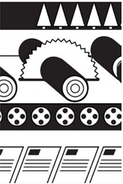

> Entra un elmento `x` y sale un elemento `y`. En el caso de una variable.

### Explicación de imagen

Función => Maquina que va a procesar las cosas.

Una función es una **regla** donde a cada elemento de un *conjunto A* se le **asigna** un elemento de un *conjunto B*.

Las funciones las podemos ver como diagramas

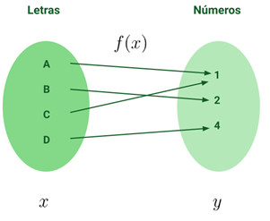

- Conjunto A: Letras
- Conjunto B: Números

### OJO: ESTO NO ES FUNCION

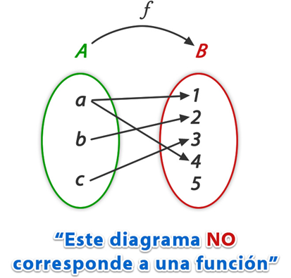

## Formas de representar una función

- Verbalmente
- Númericamente
- Visualmente
- Algebraicamente

### Verbalmente:

- A cada letra del abecedario se le asigna un número entero diferente.
- El precio aumenta en 2 dólares por cada kilómetro recorrido

## Numéricamente

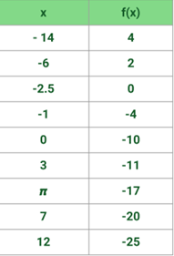

- x: Variable independiente
- y: Variable dependiente

### Visualmente:

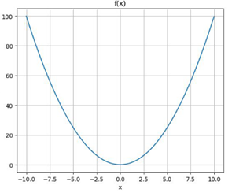

Esta es una parabola, podemos ver que cuando `x=-5` `y=25` y también cuando `x=5` `y=25`. Esto cumple con la definición de función. Es decir a la variable `x` en *2 valores diferentes* puede tener **un mismo valor de `y`**, **pero no puede suceder al reves**;

> es decir para un valor de `x` que tenga *2 valores diferentes de `y`*

### Algebraicamente

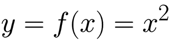

### Prueba gráfica para funciones

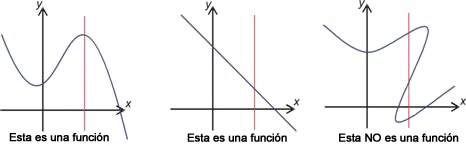